# Analyses

```python
twitter_clean.retweet_count.mean()
```

```
2646.568338702255
```

```python
twitter_clean.favorite_count.mean()
```

```
8589.699953980671
```

## Most commonly used words in tweets

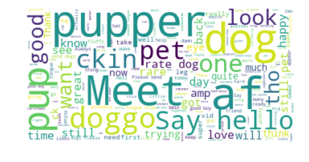

```
<wordcloud.wordcloud.WordCloud at 0x1c1acc0128>
```

```python
all_text = " ".join(rev for rev in twitter_clean.text)
stop_words = ["https", "co", "RT"] + list(STOPWORDS)
wordcloud = WordCloud(stopwords=stop_words, background_color="white").generate(all_text)
plt.imshow(wordcloud, interpolation='bilinear')
plt.axis("off")
plt.show()
wordcloud.to_file("tweet_word_cloud.png")
```

## Number of images classified as dogs vs number of classified as not dogs in predictions

```python
pred_len = image_pred_clean.shape[0]
dogs_in_predictions = [image_pred_clean.p1_dog.sum(), image_pred_clean.p2_dog.sum(),image_pred_clean.p3_dog.sum()]
not_dog_predictions = [pred_len - image_pred_clean.p1_dog.sum(), pred_len - image_pred_clean.p2_dog.sum(), pred_len - image_pred_clean.p3_dog.sum()]
```

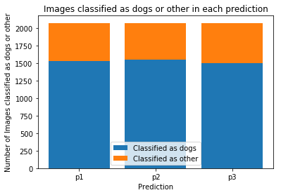

```python
dog_nodog_labels = ["p1", "p2", "p3"]
dogs_bar = plt.bar(range(3), dogs_in_predictions)
nondogs_bar = plt.bar(range(3), not_dog_predictions, bottom=dogs_in_predictions)
plt.xticks(range(3), labels=dog_nodog_labels )
plt.xlabel("Prediction")
plt.ylabel("Number of Images classified as dogs or other")
plt.legend((dogs_bar[0], nondogs_bar[0]), ('Classified as dogs', 'Classified as other'))
plt.title("Images classified as dogs or other in each prediction")
plt.savefig("dog_predictions.png")
plt.show()
```

## Average confidence level in predictions

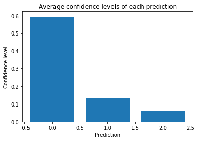

```python
conf_levels = [image_pred_clean.p1_conf.mean(), image_pred_clean.p2_conf.mean(), image_pred_clean.p3_conf.mean()]
plt.bar(range(3), conf_levels)
plt.xlabel("Prediction")
plt.ylabel("Confidence level")
plt.title("Average confidence levels of each prediction")
plt.savefig("conf_levels.png")
plt.show()
```

The confidence level of predictions seem to be high for the first prediction and it decreases with further predictions.

## Linear Relationship between retweets and likes

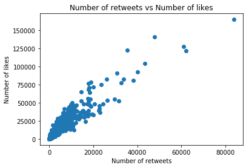

```
Correlation Coefficient:  0.9276009779095876
```

```python
plt.scatter(twitter_clean.retweet_count, twitter_clean.favorite_count)
plt.xlabel("Number of retweets")
plt.ylabel("Number of likes")
plt.title("Number of retweets vs Number of likes")
plt.savefig("rt_vs_fav.png")
plt.show()
rt_fc_corr = twitter_clean["retweet_count"].corr(twitter_clean.favorite_count)
print("Correlation Coefficient: ", rt_fc_corr)
```

From the above scatter plot and the pearson correlation coefficient, it is evident that there exists a strong linear relationship betweet retweets and likes. It is also evident that the relationship is positively associated denoting that increase in retweet counts is associated with increase in likes for a tweet.|

## Linear Regression model to predict number of likes for a tweet

```python
twitter_clean["intercept"] = 1
rt_fav_lm = sm.OLS(twitter_clean["favorite_count"], twitter_clean[["intercept", "retweet_count", "rating_numerator"]])
rt_fav_result = rt_fav_lm.fit()
rt_fav_result.summary()
```

OLS Regression Results

| Dep. Variable: | favorite_count | R-squared: | 0.860 |
| --- | --- | --- | --- |
| Model: | OLS | Adj. R-squared: | 0.860 |
| Method: | Least Squares | F-statistic: | 6690. |
| Date: | Thu, 03 Jan 2019 | Prob (F-statistic): | 0.00 |
| Time: | 01:49:13 | Log-Likelihood: | -21461. |
| No. Observations: | 2173 | AIC: | 4.293e+04 |
| Df Residuals: | 2170 | BIC: | 4.295e+04 |
| Df Model: | 2 |  |  |
| Covariance Type: | nonrobust |  |  |

|  | coef | std err | t | P>\|t\| | [0.025 | 0.975] |
| --- | --- | --- | --- | --- | --- | --- |
| intercept | 1996.1742 | 119.337 | 16.727 | 0.000 | 1762.147 | 2230.201 |
| retweet_count | 2.4925 | 0.022 | 115.668 | 0.000 | 2.450 | 2.535 |
| rating_numerator | -0.2305 | 2.118 | -0.109 | 0.913 | -4.384 | 3.923 |

| Omnibus: | 598.937 | Durbin-Watson: | 1.580 |
| --- | --- | --- | --- |
| Prob(Omnibus): | 0.000 | Jarque-Bera (JB): | 15066.553 |
| Skew: | 0.720 | Prob(JB): | 0.00 |
| Kurtosis: | 15.819 | Cond. No. | 6.36e+03 |

Warnings:  
[1] Standard Errors assume that the covariance matrix of the errors is correctly specified.  
[2] The condition number is large, 6.36e+03. This might indicate that there are  
strong multicollinearity or other numerical problems.

## Linear relationship between retweet_count and rating_numerator

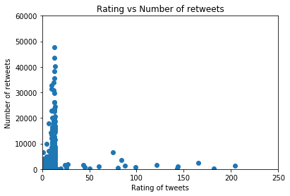

```
Correlations Coefficient:  0.005190602436517753
```

```python
plt.scatter(twitter_clean.rating_numerator, twitter_clean.retweet_count)
plt.axis([0, 250, 0, 60000])
plt.xlabel("Rating of tweets")
plt.ylabel("Number of retweets")
plt.title("Rating vs Number of retweets")
plt.savefig("rt_vs_rating.png")
plt.show()
print("Correlations Coefficient: ", twitter_clean["rating_numerator"].corr(twitter_clean.retweet_count))
```

There seems to be no linear relationship existing between the rating a dog receives and the number of retweets that a tweet receives.